# Ecological Classical Political Economy

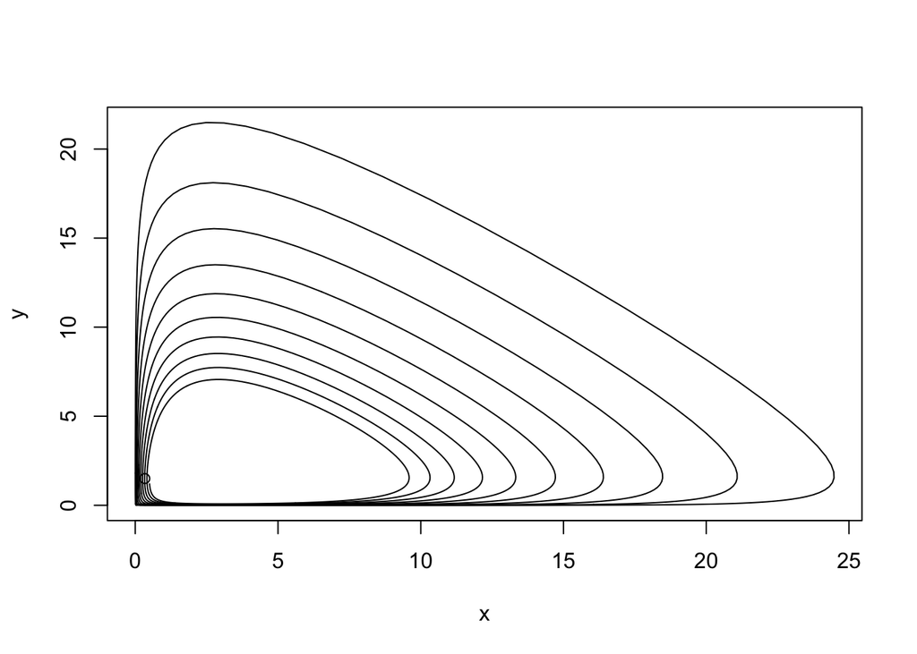

```r
# Phase Space
plot(x,y,type='l')
points(delta/gamma,alpha/beta)
```

We are not observing closed orbits and stable oscillations. How so? The problem is discretization, which amplifies the oscillations indefinitely by adding ‘energy’ to the system at each step. In order to address this issue, we need to compute the solution of the system of continuous differential equations. Fortunately, there is already a `R` package for that called `deSolve`, which has the function `ode`.

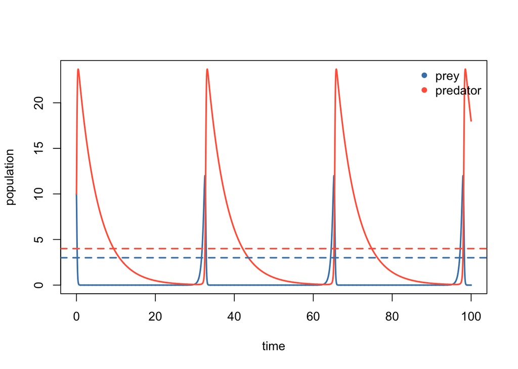

```r
library(deSolve)

# We define the function to give to ode
LotVmod <- function (Time, State, Pars) {
  with(as.list(c(State, Pars)), {
    dx = x*(alpha - beta*y)
    dy = -y*(gamma - delta*x)
    return(list(c(dx, dy)))
  })
}

# Parameters of the Model
Pars <- c(alpha = 2, beta = .5, gamma = .2, delta = .6)
State <- c(x = 10, y = 10)
Time <- seq(0, 100, by = .01)

# Compute the Solution and Plot it
solution <- as.data.frame(ode(func = LotVmod, y = State, parms = Pars, times = Time))

plot(solution$time,solution$x,xlab = "time", ylab = "population",col='steelblue',lwd=2,type='l',ylim=c(0,max(solution[,c('x','y')])))
lines(solution$time,solution$y,col='tomato',lwd=2)
abline(h=Pars['delta']/Pars['gamma'],lty=2,col='steelblue',lwd=2) # fixed point x
abline(h=Pars['alpha']/Pars['beta'],lty=2,col='tomato',lwd=2) # fixed point y
legend("topright", c("prey","predator"),col=c('steelblue','tomato'),pch=16,bty='n')
```

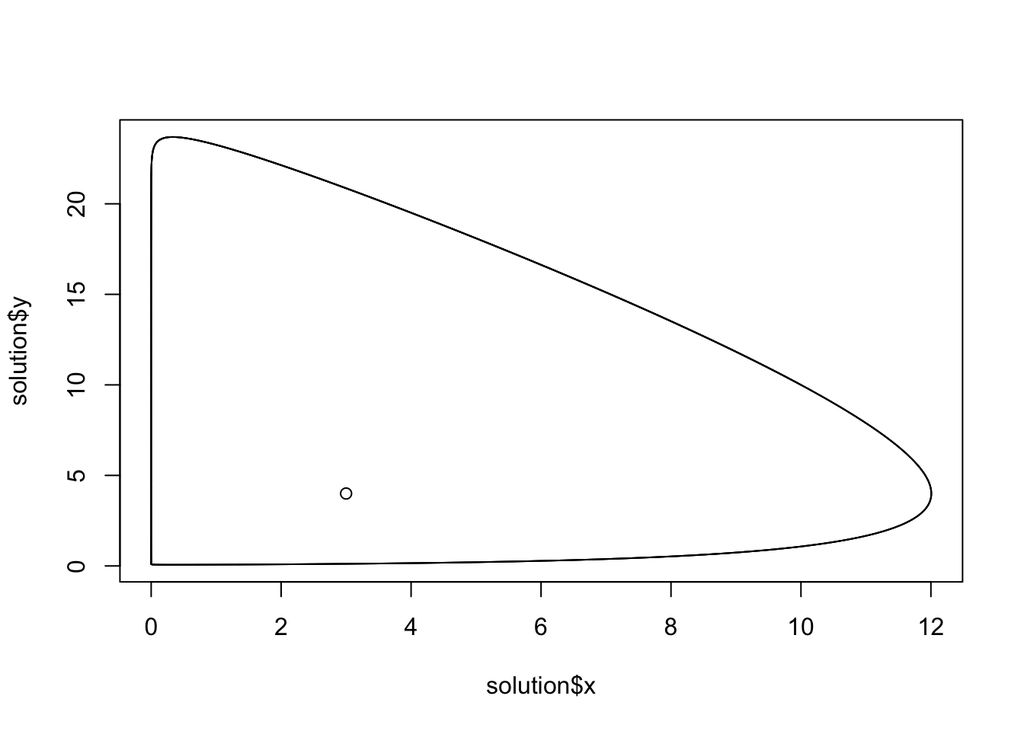

```r
# Phase Space
plot(solution$x,solution$y,type='l')
points(Pars['delta']/Pars['gamma'],Pars['alpha']/Pars['beta']) # fixed point
```

Let’s try the former set of parameters now.

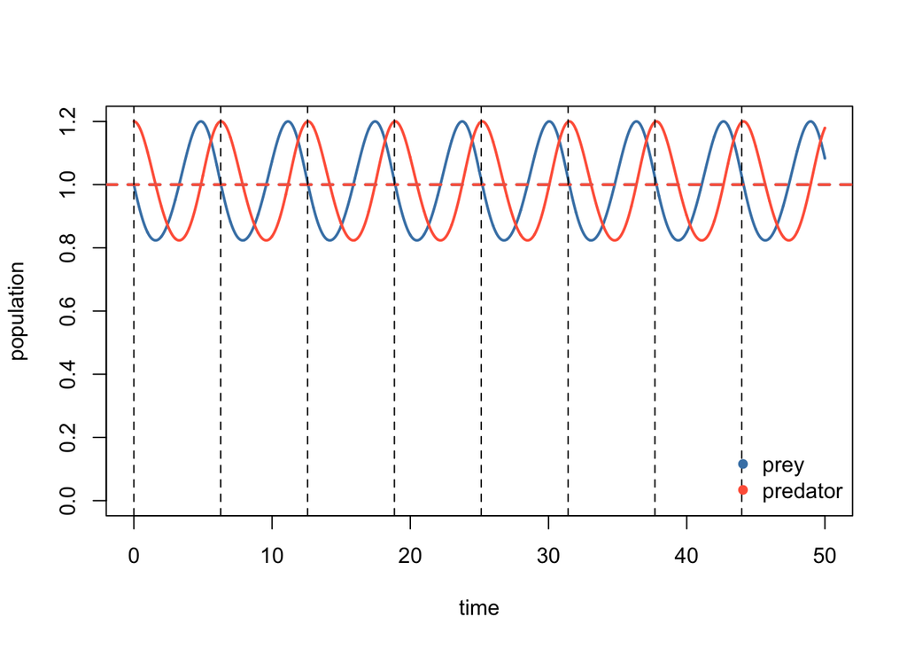

```r
Pars <- c(alpha = 1, beta = 1, gamma = 1, delta = 1)
State <- c(x = 1, y = 1.2)
Time <- seq(0, timelength, by = interval)

# Compute the Solution and Plot it
solution <- as.data.frame(ode(func = LotVmod, y = State, parms = Pars, times = Time))

plot(solution$time,solution$x,xlab = "time", ylab = "population",col='steelblue',lwd=2,type='l',ylim=c(0,max(solution[,c('x','y')])))
lines(solution$time,solution$y,col='tomato',lwd=2)
abline(h=Pars['delta']/Pars['gamma'],lty=2,col='steelblue',lwd=2) # fixed point x
abline(h=Pars['alpha']/Pars['beta'],lty=2,col='tomato',lwd=2) # fixed point y
abline(v=seq(0,timelength,by=2*pi),lty=2) # the period is 2*pi/frequency, where frequency is 1
legend("bottomright", c("prey","predator"),col=c('steelblue','tomato'),pch=16,bty='n')
```

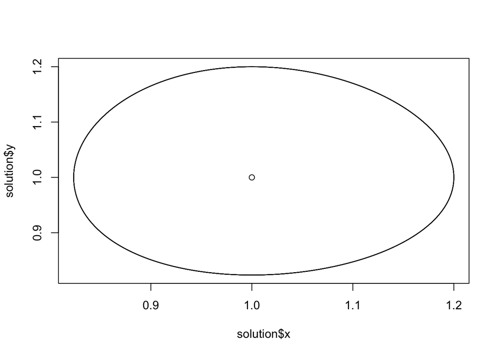

```r
# Phase Space
plot(solution$x,solution$y,type='l')
points(Pars['delta']/Pars['gamma'],Pars['alpha']/Pars['beta']) # fixed point
```

Let’s try random parameters for 4 random initial conditions:

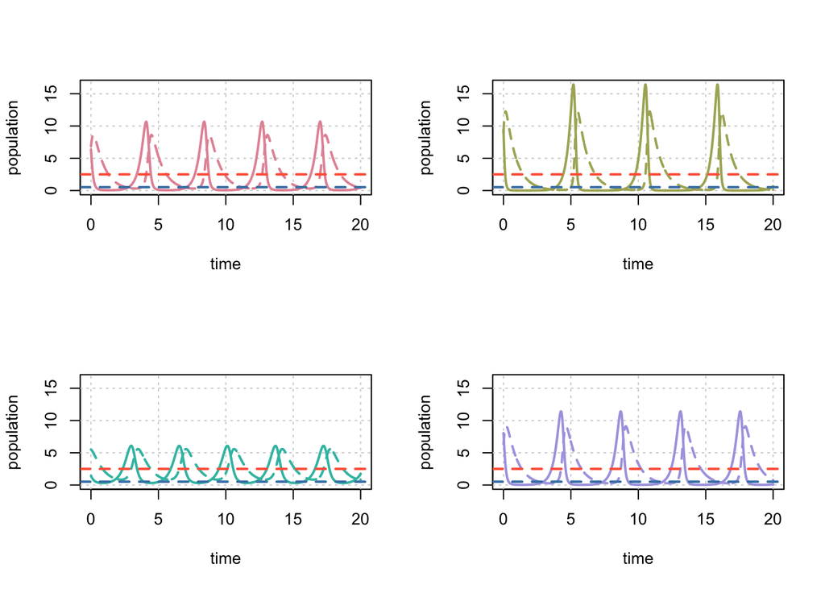

```r
Pars <- c(alpha = 3, beta = 1.2, gamma = 1.3, delta = 0.67)
timelength<-20
Time <- seq(0, timelength, by = interval)

# Compute the Solution and Plot it
solution <- list()
for(i in 1 : 4)
{
  State <- c(x = runif(1,0,10), y = runif(1,0,10))
  solution[[i]]<-as.data.frame(ode(func = LotVmod, y = State, parms = Pars, times = Time))
}

ymax <- max(sapply(solution,function(x){max(x[,c('x','y')])}))

par(mfrow=c(2,2))
for(i in 1 : 4)
{
  plot(NA,xlab = "time", ylab = "population",ylim=c(0,ymax),xlim=c(0,timelength))
  grid()
  lines(solution[[i]]$time,solution[[i]]$x,col=rainbow_hcl(n=4)[i],lwd=2)
  lines(solution[[i]]$time,solution[[i]]$y,col=rainbow_hcl(n=4)[i],lwd=2,lty=2)
  abline(h=Pars['delta']/Pars['gamma'],lty=2,col='steelblue',lwd=2) # fixed point x
  abline(h=Pars['alpha']/Pars['beta'],lty=2,col='tomato',lwd=2) # fixed point y
}
```

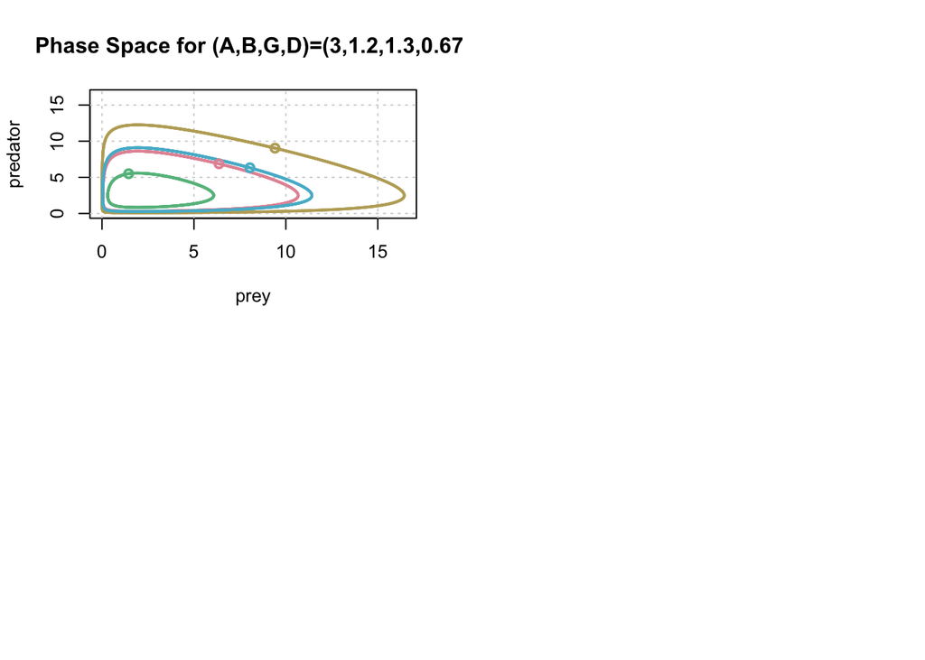

```r
# Phase Space
plot(NA,xlim=c(0,ymax),ylim=c(0,ymax),xlab='prey',ylab='predator',main=paste0('Phase Space for (A,B,G,D)=(',paste(as.vector(Pars),collapse=","),')'))
grid()
for(i in 1:4){lines(solution[[i]]$x,solution[[i]]$y,col=rainbow_hcl(n=5)[i],lwd=2)}
for(i in 1:4){points(solution[[i]]$x[1],solution[[i]]$y[1],col=rainbow_hcl(n=5)[i],lwd=2)}
```

# The Goodwin Model of Class Struggle

> The main thrust of the Goodwin model is that distributional conflict produces endogenous cycles in employment and the labor share.

The key element through which this happens is the fact that out of a balanced growth path –a path where all variables grow at the same rate, namely the growth rate of labor productivity in the conventional wage share model– wages and labor productivity might grow at different rates. In particular, upward or downward pressure on wages may result from tightness in the labor market. The employment rate can be used as a measure of labor market tightness.

The economic intuition is the following. Suppose the economy is expanding, and employment increases. Higher labor demand generates wage inflation which, as long as real wages increase more than labor productivity, increases the wage share in output. If, consistently with the Classical view, workers do not save, the resulting decrease in the profit share will act in reducing future investment and output – i.e. a profit squeeze. But then the economy is down, and lower labor demand will then correspond to lower output, leading the way to lower wage inflation or even wage deflation. The labor share will decrease. But a higher profit share will produce a surge in investment, which will generate higher employment, thus improving workers’ bargaining power and consequently wages. At this point, the wage share has increased, and the cycle can repeat itself [Tavani, Notes on Goodwin].

## Assumptions

- steady technical progress (disembodied)
- steady growth in the labour force
- only two factors of production, labour and capital, both homogeneous and non-specific
- all quantities real and net
- all wages consumed, all profits saved and invested (classical condition; constant proportional savings)
- a constant capital-output ratio
- a real wage rate which rises in the neighbourhood of full employment, i.e. $\frac{w}{w} = -\gamma + \rho v$

## Model

$q$ is output, $k$ is capital, $w$ is the wage rate, $a=a_0 e^{\alpha t}$ is labour productivity, where $\alpha$ is constant, $\sigma$ is the capital-output ratio (inverse of capital productivity), $u=w/a$ is the labour share of income, $n=n_0 e^{\beta t}$ is labour supply with constant $\beta$, $l=q/a$ is employment, and $v=l/n$ is the employment rate.

Investment $\dot{k}$ comes from profits, which are the capital share of income $l-w/a$ times output $q$,
$$\dot{k} = (l - w/a)q$$
The profit rate is
$$\frac{\dot{k}}{k} = \frac{(l - w/a)q}{k} = \frac{l - w/a}{\sigma}$$
$$\frac{\dot{q/l}}{q/l} =
\frac{\dot{q}}{q}- \frac{\dot{l}}{l} = \alpha$$
so that
$$\frac{\dot{l}}{l} = \frac{l - w/a}{\sigma} -
\alpha$$
Then, we compute for the labour share of income
$$\frac{\dot{u}}{u} = \frac{\dot{w}}{w} - \alpha =
- (\alpha + \gamma) + \rho v$$
We finally obtain the equivalent of the Lotka-Volterra oscillations for class struggle, where the wage share of income $u$ plays the role of predator and the employment rate $v$ plays the role of prey:
$$\dot{v} = v \left( \underbrace{[\frac{1}{\sigma}-
(\alpha+\beta)]}_{\alpha^*} - \underbrace{\frac{1}{\sigma}}_{\beta^*} u
\right) = v (\alpha^* - \beta^* u)$$
$$\dot{u} = u \left( -\underbrace{[\alpha + \gamma]}_{\gamma^*} +
\underbrace{\sigma}_{\delta^*} v \right) = u (-\gamma^* + \delta^* v)$$

> ``In this form we recognize the Volterra case of prey and predator. To some extent, the similarity is purely formal, but not entirely so. It has long seemed to me that Volterra’s problem of the symbiosis of two populations –partly complementary, partly hostile– is helpful in the understanding of the dynamical contradictions of capitalism, especially when stated in a more or less Marxian form.” Goodwin (1982)

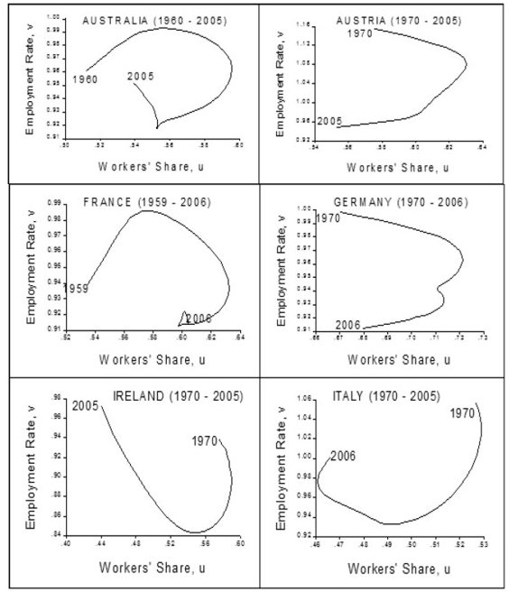

*Clockwise Cycles in the Employment-Distribution Space* Garcı́a Molina and Herrera Medina (2010)

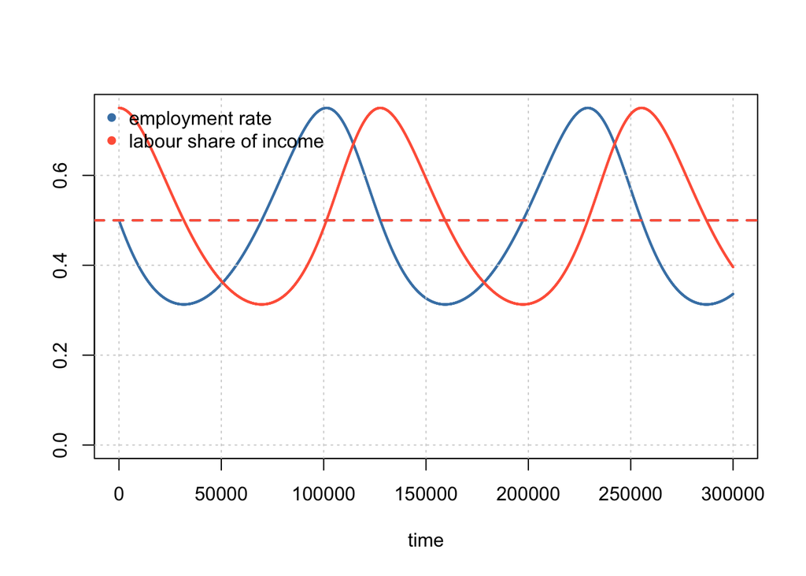

```r
alpha <- 0.25 # labor productivity growth rate
sigma <- 1  # capital/output ratio
beta <- 0.25 # population growth rate
gamma <- 0.25 # intercept of the wage curve close to full employment

parameters <- c(1/sigma - alpha - beta,  # alpha*
                1/sigma,  # beta*
                sigma,  # delta*
                alpha + gamma) # gamma*

orbit <- lotka.volterra(pars = parameters, time.length = 30, interval = 0.0001, init = c(0.5, 0.75))

plot(orbit$x, type='l' , xlim = c(0, nrow(orbit)), ylim=c(0, max(orbit)), xlab = 'time', ylab='', col='steelblue', lwd=2)
grid()
lines(orbit$y, col = 'tomato', lwd=2)

abline(h = parameters[4]/parameters[3], lty=2, col = 'steelblue', lwd = 2) # fixed point for prey
abline(h = parameters[1]/parameters[2], lty=2, col = 'tomato', lwd = 2) # fixed point for predator

legend('topleft',c('employment rate','labour share of income'), col = c('steelblue','tomato'), pch=16, bty='n')
```

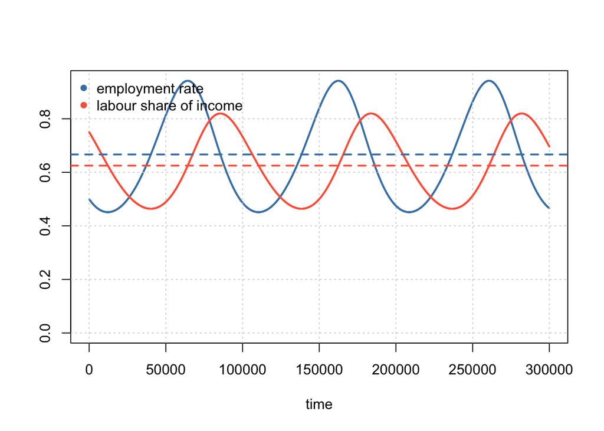

```r
alpha <- 0.25 # labor productivity growth rate
sigma <- 0.75  # capital/output ratio
beta <- 0.25 # population growth rate
gamma <- 0.25 # intercept of the wage curve close to full employment

parameters <- c(1/sigma - alpha - beta,  # alpha*
                1/sigma,  # beta*
                sigma,  # delta*
                alpha + gamma) # gamma*

orbit <- lotka.volterra(pars = parameters, time.length = 30, interval = 0.0001, init = c(0.5, 0.75))

plot(orbit$x, type='l' , xlim = c(0, nrow(orbit)), ylim=c(0, max(orbit)), xlab = 'time', ylab='', col='steelblue', lwd=2)
grid()
lines(orbit$y, col = 'tomato', lwd=2)

abline(h = parameters[4]/parameters[3], lty=2, col = 'steelblue', lwd = 2) # fixed point for prey
abline(h = parameters[1]/parameters[2], lty=2, col = 'tomato', lwd = 2) # fixed point for predator

legend('topleft',c('employment rate','labour share of income'), col = c('steelblue','tomato'), pch=16, bty='n')
```

# The Flaschel-Semmler Model

## Classical Gravitation

> The Classical political economists did not believe that this competitive process would lead to an actual equalization of realized or prospective profit rates at any moment in time. The movement of capital from one line of production to another would upset the conditions of other lines of production, which, together with disturbances from outside the national economy, would always prevent the realization of a state of equalization of profit rates. They expected to see a ceaseless fluctuation of prices and profit rates as the outcome of the competitive process, rather than the achievement of a state of “equilibrium” in which prices settled down to levels (“natural prices”) at which profit rates would be equalized. Foley (2003)

Nonetheless, the concept of this equilibrium state (which has come to be referred to as **“long-period” equilibrium**) plays a natural and important part in the analysis of the real economy. The competitive dynamic, even if it is not stable in the mathematical sense of pushing the system to an equilibrium of equal profit rates, will prevent prices and profit rates from wandering indefinitely far from their equilibrium values. This idea is expressed by arguing that observed market prices tend to gravitate around the natural prices at which profit rates would be equalized. The abstract concept of long-period equilibrium natural prices plays a crucial analytical role in understanding the concrete fluctuations of observable market prices. Foley (2003)

> The Flaschel-Semmler model of multi-sector growth (Flaschel and Semmler 1987) with circulating capital and constant technology describes price (as prey) and quantity (as predator) oscillations over time around the equilibrium values of *N* prices *p* (a row vector) and *N* quantities *x* (a column vector) of the Sraffa-von Neumann system (Von Neumann 1945; Sraffa 1960).

The neoclassical adjustment process is generally regarded to be insufficient to ensure convergence to equilibrium on its own (Hahn 1970). As Flaschel and Semmler note, this led “neoclassical equilibrium theorists to avoid such problems completely by restricting their attention exclusively to equilibrium situations and assuming a ‘law of demand and supply’ in operation which works with infinite speed in an asymptotically stable manner” (Flaschel and Semmler 1987). As a consequence, adjustment to short-run equilibrium is critically taken as a matter of fact without characterizing the dynamical process by which it happens, thus treating the time dimension in purely hypothetical, yet not real, terms.

## Equilibrium

Equilibrium values in quantities are obtained from the **equality of supply and demand**,
$$\underbrace{B x^*}_{\text{outputs (supply)}} = R
\underbrace{A x^*}_{\text{inputs (demand)}}$$
while equilibrium values in prices from the **uniformity of profit rates**,
$$\underbrace{p^* B}_{\text{unit revenues}} =
R \underbrace{p^* A}_{\text{unit costs}}$$
Balanced Growth : $p^*$ and $x^*$ are the positive eigenvectors of $A$, the matrix of input-output coefficients, and $R = 1+r^*$, the expansion factor, corresponds to the dominant eigenvalue.

In scalar notation,
$$\sum_j b_{ij} x^*_j
= R \sum_j a_{ij} x^*_j \quad i=1,...,N$$
$$\sum_i p^*_i b_{ij} = R \sum_i p^*_i a_{ij}
\quad j=1,...,N$$

## Constant-Technology Dynamics

The model is based on the dynamic cross-dual linear adjustment between prices and quantities.

**Law of Excess Demand**

Demand-supply imbalances trigger changes in prices
$$\left(\frac{\dot{p}}{p}\right)^T = - \delta_{p} [B-RA] x = \delta_p
[\underbrace{R A x}_{\text{demand}} - \underbrace{Bx}_{\text{supply}}]$$

**Law of Excess Profitability**

Profit imbalances trigger changes in quantities

$$\frac{\dot{x}}{x} = + \delta_x [B-RA]^T
p^T = \delta_x [\underbrace{B^Tp^T}_{\text{revenue}} -
R \underbrace{A^Tp^T}_{\text{cost}}]$$
$\delta_p$ and $\delta_x$ are vectors of adjustment coefficients to estimate econometrically in order to calibrate empirically the model.

### Econometrics

The empirical calibration involves the econometric estimation of vectors of country-, sector-specific adjustment coefficients $\delta^i_p$ and $\delta^i_x$ that relate growth rates in prices and quantities to supply-demand and revenue-cost imbalances, respectively (i.e. excess demand and excess profitability), in a linear form:
$$y_{a,it} = \delta^i_a x_{a,it}
\qquad a = p,x; \quad i=1,...,N; \quad t=2000,...,2014$$
This problem can be addressed applying a hierarchical mixed-effects linear model with varying slopes with respect to the country sector.

## Computation

First, call the required packages (only for visualization) and define the technological matrix $A$. In this code, there are three different technological matrices of different size (number of sectors: 2, 4, and 7) from which we can compute its dynamical evolution in prices and quantities. While the first two are toy matrices, the latter corresponds to a simple version of the US economy with 7 sectors (Miller and Blair 2009). We compute the equilibrium triplet where $r0$ is the equilibrium profit rate, $p0$ is the equilibrium price vector, and $x0$ is the equilibrium output vector. In order to do so, we have to be careful with the dimensions of our variables (whether we have column or row vectors). $gam$ corresponds to the $\gamma$ adjustment parameter.

```r
# FLASCHEL-SEMMLER MODEL
# WITH ADJUSTMENT TO STABILIZE THE OSCILLATIONS
library(colorspace)
library(scales)
library(RColorBrewer)

timelength <- 1000
# A <- matrix(c(0.625,0.2,0.8,0.05), nrow = 2)
A <- matrix(c(0.1,0.4,0,0.3,0,0.1,0.2,0.5,0.3,0.2,0.3,0,0.1,0.1,0.5,0.1), nrow = 4)
A <- matrix(c(.2008,.001,.0034,.1247,.0855,.0897,.0093,0,.0658,.0002,.0684,.0529,.1668,.0129,.0011,.0035,.0012,.1801,.0914,.1332,.0095,.0338,.0219,.0021,.2319,.0952,.1255,.0197,.0001,.0151,.0035,.0339,.0645,.1647,.019,.0018,.0001,.0071,.0414,.0315,.2712,.0184,.0009,.0026,.0214,.0726,.0528,.1873,.0228), nrow = 7)

K <- nrow(A)
r_eq <- r0 <- Re(1/eigen(A)$values[1] - 1)
q0 <- Re(eigen(A)$vectors[,1])

leontief <- solve(diag(K) - A) # Leontief Requirements Matrix

y0 <- 100*t(t(q0)) # Final Demand: we multiply the vector by 50

dx <- rep(0.1, K) # Adjustment parameters
dp <- rep(0.01, K) # Adjustment parameters
gam <- 0.98 # Gamma

x0 <- leontief %*% y0 # Input Vector # (A %*% p0) capital/output # actually p0 %*% A
p0 <- Re(t(eigen(t(A))$vectors[,1]))
# x0<-c(0.45,0.4)
# p0<-c(0.6,0.6)
# (diag(K)-R*A) %*% x0 should be zero (i.e. there is no extra surplus)
R <- 1 + r_eq
```

In the following code, we initialize our simulations, where we create a 3-dimensional array called capital defined by number of sectors $\times$ number of attributes $\times$ number of iterations where we will save the synthetic data we compute. Initial conditions are the equilibrium values of prices and quantities plus an error. Attributes are the capital stock $M$, the sector index $k$, the technological inputs for sector $k$, price $p$, profit rate $r$, quantity $X$, sales $S$, demand $D$, profits $pi$, capital/output ratio $K$, and growth rate $g$.

```r
# INITIALIZATION
labels <- c('M','k',paste0('a',1:K),'p','r','X','S','D','pi','K','g')
K <- nrow(A)
capital <- array(0,dim=c(K,length(labels),timelength),dimnames=list(paste0('K',c(1:K)),labels,paste0('t',c(1:timelength))))

capital[,paste0('a',1:K),1]<-A
capital[,c('p','X'), 1] <- c(p0, x0)
capital[,'X', 1]<- x0 + 5*rep(c(.1,-.1),K)[1:K]
capital[,'p', 1]<- p0 - 0.01*rep(c(.1,-.1),K)[1:K]
capital[,'M',1] <- capital[,'p',1] %*% A * capital[,'X',1]

capital[,c('pi','g'),1] <- NA

capital[,'r',1] <- capital[,'p',1]*capital[,'X',1]/(capital[,'p',1] %*% A * capital[,'X',1])-1
```

Once we have set up the initial conditions, we can start the simulation, following the dynamical system:

$$x_{t+1} = x_t + \langle d_x \rangle
\langle x \rangle \left( [B-RA]^T p^T + \gamma s \right)$$
$$p_{t+1} = p_t - \langle d_p \rangle \langle p_t
\rangle (B - RA) x_t$$

where there is an additional stabilization term $S$:

$$s = \frac{d}{dt} [B - RA]^T p^T$$

```r
for (t in 1:(timelength-1))
{
  # Compute price and quantity
  capital[,'p',t+1] <- capital[,'p',t] - dp * t((diag(K) - R * A) %*% t(t(capital[,'X', t])))*capital[,'p', t]

  s<-t(diag(K)-R*A) %*% t(t(capital[,'p',t+1]-capital[,'p',t]))

  capital[,'X',t+1]<-capital[,'X',t]+dx*(t(diag(K)-R*A) %*% t(t(capital[,'p',t]))+gam*s)*capital[,'X',t]


  # Auxiliary Variables
  capital[,'S',t+1]<-capital[,'X',t+1]
  capital[,'D',t+1]<-capital[,'X',t+1]-(A %*% t(t(capital[,'X',t+1])) + y0)
  capital[,'M',t+1]<-capital[,'p',t] %*% A * capital[,'X',t+1]
  capital[,'g',t]<-capital[,'M',t+1]/capital[,'M',t]-1
  capital[,'pi',t+1]<-capital[,'p',t+1]*capital[,'X',t+1]
  capital[,'K',t+1]<-capital[,'M',t+1]/capital[,'X',t+1]
  capital[,'r',t+1]<-capital[,'p',t]*capital[,'X',t]/(capital[,'p',t] %*% A * capital[,'X',t])-1
}
```

Once we have already computed the capital array, we can visualize it.

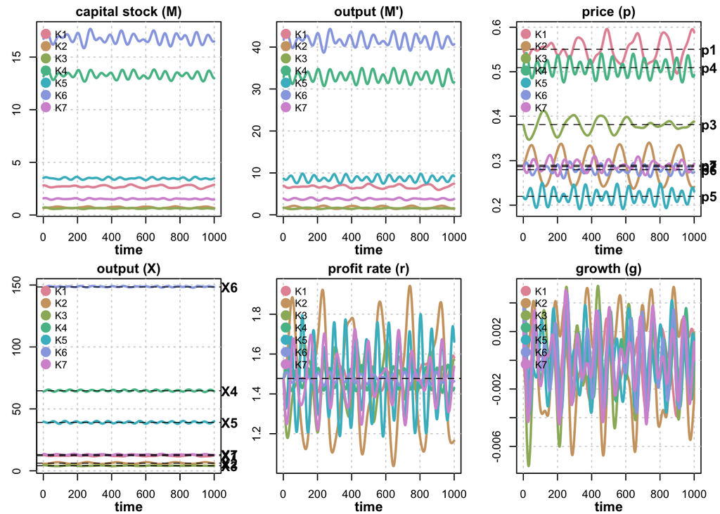

```r
colores<-rainbow_hcl(K)
lab_<-c('capital stock (M)',"output (M')",'price (p)','output (X)','profit rate (r)', 'growth (g)')
names(lab_)<-c('M','pi','p','X','r','g')

tval<-1:timelength

par(mfrow=c(2,3),mar=c(3, 2.7, 1.6, 1.4),oma=c(0,0,0,0))

for(lab in names(lab_))
{
  yli<-c(min(Re(capital[,lab,tval]),na.rm=T),max(Re(capital[,lab,tval]),na.rm=T))
  # yli<-c(min(avg[,lab,tval],na.rm=T),max(avg[,lab,tval],na.rm=T))

  if(lab=='x'){yli[1]<-0}
  #if(lab=='p'){yli[1]<-4}

  plot(NA,xlim=c(min(tval),max(tval)),ylim=yli,xlab='',ylab='',main=lab_[lab],font.lab=2,cex.lab=1)
  grid()

  #if(lab=='r' | lab=='p'){for(i in 1:N){points(tval,capital[i,lab,tval],col=alpha(colori[N-i+1],0.25),cex=0.8,pch=16)}} else{for(i in 1:N){lines(tval,capital[i,lab,tval],col=alpha(colori[N-i+1],0.25),lwd=2)}}

  for(k in 1:K){lines(tval,capital[k,lab,tval],col=colores[k],lwd=2.25)}
  # if(lab=='x'){for(k in 1:K){lines(tval,yli[2]*N_h[tval,k]/N,col=rgb(t(col2rgb(colores[k])/1.4),maxColorValue=255),lwd=1.9,lty=3)}}
  # if(lab=='x'){axis(4,at=seq(0,yli[2],length.out=5),labels=seq(0,yli[2],length.out=5)*N/yli[2])}
  #if(lab=='p'){for(k in 1:K){lines(tval,p0[k,tval],col='black',lwd=0.8,lty=2)}}

  if(lab=='p'){abline(h=p0,col='black',lwd=0.8,lty=2)}
  if(lab=='p'){mtext(paste0('p',1:K),side=4,at=p0,las=1,cex=0.8,font=2)}
  if(lab=='X'){abline(h=x0,col='black',lwd=0.8,lty=2)}
  if(lab=='X'){mtext(paste0('X',1:K),side=4,at=x0,las=1,cex=0.8,font=2)}
  if(lab=='r'){abline(h=r_eq,lty=2)}

  legend('topleft',paste0('K',1:K),col=colores,pch=16,pt.cex=2,cex=0.9,bty='n')
  mtext('time',side=1,cex=0.8,line=2,font=2)
}
```

# Early Agent-Based Models

## Cellular Automata

> A cellular automaton is a discrete model studied in computer science, mathematics, physics, complexity science, theoretical biology and microstructure modeling.

A cellular automaton consists of a regular grid of cells, each in one of a finite number of states, such as on and off (in contrast to a coupled map lattice). The grid can be in any finite number of dimensions. For each cell, a set of cells called its neighborhood is defined relative to the specified cell. An initial state (time t = 0) is selected by assigning a state for each cell. A new generation is created (advancing t by 1), according to some fixed rule (generally, a mathematical function) that determines the new state of each cell in terms of the current state of the cell and the states of the cells in its neighborhood. Typically, the rule for updating the state of cells is the same for each cell and does not change over time, and is applied to the whole grid simultaneously, though exceptions are known, such as the stochastic cellular automaton and asynchronous cellular automaton.

> Hence, we can consider CA as dynamical systems with (often) deterministic rules $R$, operating on discrete time $T$, over discrete space $S$.

The theory of cellular automata, the **“canonical complex system”** (Bossomaier 2008, 59), has its origin in the later work of Von Neumann, who was dissatisfied with the theory of games he had created with Oskar Morgenstern in order to understand strategic interaction (Mirowski 1992). Cellular automata were framed as a possible idealization of biological systems [von Neumann 1966], with the particular purpose of modeling biological self-reproduction [Wolfram 1983]. An automaton is a mathematically well-defined set of rules through which an entity interacts with its environment [Foley 2005]. A cellular automaton is a particular simple class of automata that lives on a graph or network. For instance, BTW’s sandpile model is an example of a cellular automaton on a two-dimensional regular lattice. Each node of the graph can take on a finite range of states.

> The key features of CAs necessary for practical applications are the locality, an evolution rule, the set of states available, the configurations feasible, and boundary conditions (Bossomaier 2008). In almost all cases, cellular automaton evolution is irreversible.

In Stephen Wolfram’s classic **classification**, cellular automata fall qualitatively into four basic behavior classes (Wolfram 1984; Bossomaier 2008):

- **Class 1** leading to stable, static configurations, akin to very short transients to mainly a point attractor: the evolution is dominated by a unique state of its alphabet for any random initial condition.
- **Class 2** settling in oscillations, akin to a limit cycle: the evolution is dominated by blocks of cells which are periodically repeated for any random initial condition.
- **Class 3** induce chaotic attractors, with aperiodic oscillations; if for a long time and for any random initial condition, the evolution is dominated by sets of cells without any defined pattern.
- **Class 4** further display complex patterns, with effectively very long transients; structured, but endlessly changing. are the really interesting ones. They display complex patterns, structured, but endlessly changing. The evolution is dominated by non-trivial structures emerging and traveling along the evolution space where uniform, periodic, or chaotic regions can coexist with these structures.

> In 1984, Wolfram conjectured Class 4 automata may be capable of **universal computation**, but a few have been proved to do so, notably by Langton Langton (1990).

Examples include: von Neumann was the first to use automata theory to study the logical intricacies of biological reproduction, detailing an infinite two-dimensional array or cellular space of identical finite automata supporting an activity interpreted as self-reproduction (Neumann 1966). Von Neumann later showed the computational power of the highly complex cellular space, with 29 states per cell, and the self-reproducing, computing construction including 40,000 cells or so. Such a cellular space is then computationally equivalent to any given Turing machine.

Wolfram 1-dimensional’s CA (Wolfram 2002) The CA are one-dimensional with the states of the cells (0 or 1) at a given time forming each row of the figure and with increasing row number going downwards showing the evolution in time according to 2N different rules where N is the number of cells.

In late 1940, John von Neumann defined life as a creation (as a being or organism) which can reproduce itself and simulate a Turing machine. Von Neumann’s cellular automata are the original expression of cellular automata, the development of which was prompted by suggestions made to John von Neumann by his close friend and fellow mathematician Stanislaw Ulam. Their original purpose was to provide insight into the logical requirements for machine self-replication, and they were used in von Neumann’s **universal constructor**.

## Conway’s Game of Life

The Game of Life, also known simply as Life, is a cellular automaton devised by the British mathematician John Horton Conway in 1970. Conway died on April 11th 2020 due to the coronavirus.

The game is a zero-player game, meaning that its evolution is determined by its initial state, requiring no further input. One interacts with the Game of Life by creating an initial configuration and observing how it evolves. It is Turing complete and can simulate a universal constructor or any other Turing machine.

The universe of the Game of Life is an infinite, two-dimensional orthogonal grid of square cells, each of which is in one of two possible states, alive or dead, (or populated and unpopulated, respectively). Every cell interacts with its eight neighbours, which are the cells that are horizontally, vertically, or diagonally adjacent.

## Self-Organized Criticality: the Sandpile Model

Following Anderson’s words, Bak and co-authors coined the notion of “self-organized criticality” from statistical mechanics (Bak, Tang, and Wiesenfeld 1987): they aimed at describing a class of dynamical systems which naturally drive them- selves to a state where interesting dynamics occurs on all scales, that is, at developing a possible explanation of the omnipresent multi-scale structures throughout the natural and social world (Creutz 1997).

> In this context, complex behavior in nature reflects the tendency of large systems with many components to evolve into a poised, “critical” state, way out of balance, where minor disturbances may lead to events, called avalanches, of all sizes.

The sandpile model generates very interesting **complex fractal patterns**, conceived as *“snapshots of systems operating at the self-organized critical state”*. Crucially, Bak et al showed the distribution of avalanches followed a power law. Power laws are relevant because:

- they are **scale-free**, that is, scaling the function with a constant a returns the same function multiplied by a−k). In other words, there is no preferred length scale, so no dimension units are well-defined.
- they **lack well-defined statistics** (the average is well-defined only if k > 2 and the variance only if k > 3; most phenomena show 2 < k < 3).
- they are **universal in the sense** that they belong to a class of universality determined by their critical exponents, revealing fundamental dynamics underlying diverse systems approaching criticality.

> Power laws are of great importance since they feature heavy or fat tails in contrast to the Gaussian distribution, so that there is an over-representation in the data of large-scale events, that is, “black swans”.

Power laws are ubiquitous in nature: for instance, the Stefan-Boltzmann law for the electromagnetic radiation of a black body, the Zipf law for the rank-frequency distribution for words in natural languages; the distribution of city sizes, of avalanches, wars, and acts of terrorism. In economics, the Pareto distribution of income [Dragulescu and Yakovenko 2001], the distribution of price changes in the stock market [Mandelbrot 1963; Farmer et al. 2005] or the Zipf-law distribution of firm sizes [Simon and Bonini 1958; Axtell 2001] are all power laws, while the stationary distribution of profit rates [Scharfenaker and Semieniuk 2016] is a double-exponential that displays a heavy tail.

## Schelling’s Urban Segregation Model

The Schelling model of segregation is an agent-based model that illustrates how individual tendencies regarding neighbors can lead to segregation. The model is especially useful for the study of residential segregation of ethnic groups where agents represent households who relocate in the city. In the model, each agent belongs to one of two groups and aims to reside within a neighborhood where the fraction of ‘friends’ is sufficiently high: above a predefined tolerance threshold value F. It is known that depending on F, for groups of equal size, Schelling’s residential pattern converges to either complete integration (a random-like pattern) or segregation. [An example here](http://nifty.stanford.edu/2014/mccown-schelling-model-segregation/).

> Schelling’s model roughly corresponds to an Ising model at temperature T = 0.

## Ising Model

The Ising model is a mathematical model of ferromagnetism in statistical mechanics. The model consists of discrete variables that represent magnetic dipole moments of atomic “spins” that can be in one of two states (+1 or 1). The spins are arranged in a graph, usually a lattice (where the local structure repeats periodically in all directions), allowing each spin to interact with its neighbors. Neighboring spins that agree have a lower energy than those that disagree; the system tends to the lowest energy but heat disturbs this tendency, thus creating the possibility of different structural phases. The model allows the identification of phase transitions, as a simplified model of reality.

> The two-dimensional square-lattice Ising model is one of the simplest statistical models to show a phase transition.

There is also a long tradition of using the Ising model and its extensions to represent social interactions and organization (Wiedlich, 1971; 1991; 2000; Callen and Shapero, 1974; Montroll and Badger, 1974; Galam et al., 1982; Orlean, 1995).

> A large set of economic models can be mapped onto various versions of the Ising model to account for social influence in individual decisions (Phan et al.,2004).

The Ising model is indeed one of the simplest models describing the competition between the ordering force of imitation or contagion and the disordering impact of private information or idiosyncratic noise, which leads already to the crucial concept of **spontaneous symmetry breaking and phase transitions** (McCoy and Wu, 1973). It is therefore not surprising to see it appearing in one guise or another in models of **social imitation** (Galam and Moscovici, 1991) and of **opinion polarization** (Galam, 2004; Sousa et al., 2005; Stauffer, 2005; Weidlich and Huebner, 2008). An illuminating way to justify the use in social systems of the Ising model (and of its many generalizations) together with a statistical physics approach (in terms of the Boltzmann factor) derives from **discrete choice models**.

```r
# INITIALIZATION
library(caTools)
N <- 100
timelength <- 1000

spin <- array(NA, dim = c(timelength+1, N, N))
spinU <- array(NA, dim = c(timelength+1, N, N))
spin[1, , ] <- matrix(sample(c(-1, 1), N^2, replace  = TRUE, prob = c(0.5, 0.5)), nrow = N, ncol = N)
#spin[1, , ] <- matrix(rep(1, N^2), nrow = N, ncol = N)
number <- c() # frequencies
temperature <- 0.1
beta  <-  1/(temperature*1.38*10^{-23})

# SIMULATION
for(t in 1:timelength)
{
#   if((t-1)%%7 == 0)
#   {
#       beta = betavector[count]
#       count <- count+1
#   }
    for(i in 1:N)
    {
        for(j in 1:N)
        {
            # Include Boundary Conditions
            i0 <- i %% N + 1
            j0 <- j %% N + 1
            iF <- (i + N - 2) %% N + 1
            jF <- (j + N -2) %% N + 1

            old <- spin[t, i, j]
            new <- -old

            val <- spin[t, i, j0] + spin[t, i0, j] + spin[t, iF, j] + spin[t, i, jF]

            oldU <- old*val
            newU <- new*val
            dU <- beta*(newU - oldU)
            spinU[t, i, j] <- newU-oldU

            if(!dU <= 0 | (exp(dU) > runif(1))) spin[t+1, i, j] <- new else spin[t+1, i, j] <- old
        }
    }
    number[t] <- table(spin[t, , ])['1']/N^2
}

spin1 <- aperm(spin, c(2, 3, 1)) # we need to change dimensions for the gif
write.gif(spin1, 'ising.gif', col = "jet", delay = 0)
# banana <- image_read("ising.gif")
# banana <- image_scale(banana, "400%") # resize the gif
# image_write(banana, "ising2.gif")
```

# More Oscillators

## Van der Pol Oscillator

The Van der Pol oscillator is a non-conservative oscillator with non-linear damping. It evolves in time according to a second-order differential equation with μ as a scalar parameter indicating the nonlinearity and the strength of the damping. Van der Pol found stable oscillations which he subsequently called relaxation-oscillations in the form of a limit cycle. When electric circuits of vacuum tubes were driven near the limit cycle, they become entrained, i.e. the driving signal pulls the current along with it. Van der Pol and his colleague, van der Mark, reported in the September 1927 issue of Nature that at certain drive frequencies an irregular noise was heard, which was later found to be the result of deterministic chaos. The Van der Pol equation has a long history of being used in both the physical and biological sciences, for instance the FitzHugh-Nagumo model for action potentials of spiking neurons.

## FitzHugh-Nagumo

The FitzHughNagumo model (FHN), named after Richard FitzHugh who suggested the system in 1961 and J. Nagumo et al. who created the equivalent circuit the following year, describes a prototype of an excitable system (e.g. a neuron). The FHN Model is an example of a relaxation oscillator because, if the external stimulus Iext exceeds a certain threshold value, the system will exhibit a characteristic excursion in phase space, before the variables v and w relax back to their rest values. Further, Iext can be considered as a Gaussian white noise that may occasionally induce the neuron to spike, as well as a coupling term with adjacent oscillators, generating interesting interactions between coupled elements.

### References

Arthur, W Brian. 2014. *Complexity and the Economy*. Oxford University Press.

Bak, Per, Chao Tang, and Kurt Wiesenfeld. 1987. “Self-Organized Criticality: An Explanation of the 1/f Noise.” *Physical Review Letters* 59 (4): 381.

Beinhocker, Eric D. 2006. *The Origin of Wealth: Evolution, Complexity, and the Radical Remaking of Economics*. Harvard Business Press.

Bhaduri, Amit, and Donald J Harris. 1987. “The Complex Dynamics of the Simple Ricardian System.” *The Quarterly Journal of Economics* 102 (4): 893–902.

Bossomaier, Terry. 2008. “Cellular Automata.” In *Applications of Complex Adaptive Systems*, edited by Yin Shan, 57–84. IGI Global.

Creutz, Michael. 1997. “Cellular Automata and Self Organized Criticality.” *Some New Directions in Science on Computers*, 147–69.

Flaschel, Peter, and Will Semmler. 1987. “Classical and Neoclassical Competitive Adjustment Processes.” *The Manchester School* 55 (1): 13–37.

Foley, Duncan K. 2003. *Unholy Trinity: Labor, Capital and Land in the New Economy*. Routledge.

Garcı́a Molina, Mario, and Eleonora Herrera Medina. 2010. “Are There Goodwin Employment-Distribution Cycles? International Empirical Evidence.” *Cuadernos de Economı́a* 29 (53): 1–29.

Goodwin, Richard M. 1982. “A Growth Cycle.” In *Essays in Economic Dynamics*, 165–70. Springer.

Hahn, Frank H. 1970. “Some Adjustment Problems.” *Econometrica: Journal of the Econometric Society*, 1–17.

Langton, Chris G. 1990. “Computation at the Edge of Chaos: Phase Transitions and Emergent Computation.” *Physica D: Nonlinear Phenomena* 42 (1-3): 12–37.

Miller, Ronald E, and Peter D Blair. 2009. *Input-Output Analysis: Foundations and Extensions*. Cambridge University Press.

Mirowski, Philip. 1992. “What Were von Neumann and Morgenstern Trying to Accomplish?” *History of Political Economy* 24 (5): 113–47.

———. 1996. “Do You Know the Way to Santa fé? Or, Political Economy Gets More Complex.” In *Interactions in Political Economy*, 27–54. Routledge.

Neumann, John von. 1966. *Theory of Self-Reproducing Automata*. University of Illinois Press.

Rosser, J Barkley. 2000. “Aspects of Dialectics and Non-Linear Dynamics.” *Cambridge Journal of Economics* 24 (3): 311–24.

Shaikh, Anwar. 2016. *Capitalism: Competition, Conflict, Crises*. Oxford University Press.

Sraffa, Piero. 1960. *Production of Commodities by Means of Commodities: Prelude to a Critique of Economic Theory*. Cambridge University Press.

Von Neumann, J. 1945. “A Model of General Economic Equilibrium.” *The Review of Economic Studies* 13 (1): 1–9.

Wolfram, Stephen. 1984. “Universality and Complexity in Cellular Automata.” *Physica D: Nonlinear Phenomena* 10 (1-2): 1–35.

———. 2002. *A New Kind of Science*. Vol. 5. Wolfram media Champaign.